# Lab 1 Assignment 3 Report

2025-11-18

### Part 1 - Plot of real data

The following plot is showing plasma glucose concentration on age where observations are colored by diabetes levels.

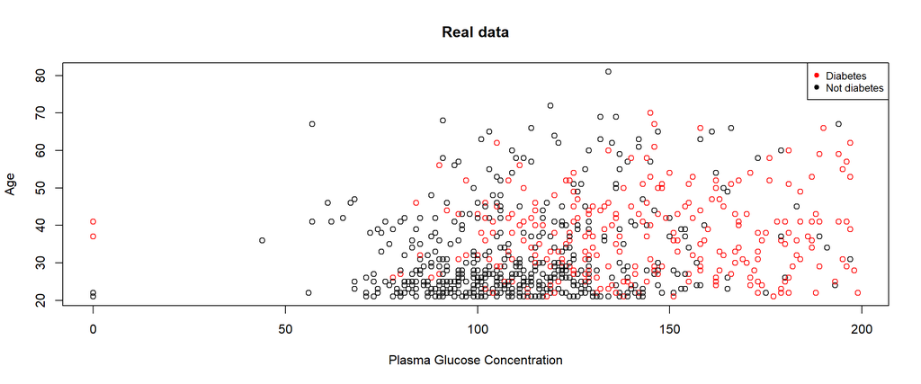

### Part 2 - Logistic regression prediction

In part 2 of assignment 3 we train a logistic regression model. The following plot has the same data points as the previous but are colored according to the predicted diabetes levels from the model:

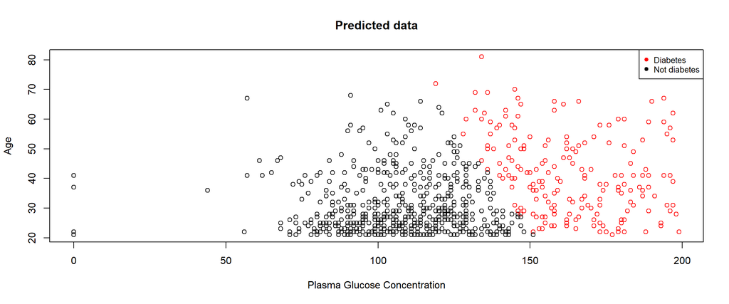

#### Report the probabilistic equation of the estimated model (i.e., how the target depends on the features and the estimated model parameters probabilistically).

The probabilistic equation for the estimation of diabetes in the model can be calculated as:
$$P(y=1 \mid x)
= \frac{1}{1 + e^{-(\beta_0 + \beta_1 x_1 + \beta_2 x_2)}}$$
where β0 = (Intercept), β1 = first parameter, β2 = second parameter, with the following values:

```
##                       (Intercept) data$plasma_glucose_concentration
##                       -5.91244906                        0.03564404
##                          data$age
##                        0.02477835
```

With the prediction threshold r=0.5 all predictions above 0.5 are classified as “diabetes” while the prediction below it are classified as “not diabetes”.

#### Misclassification of the model

The training misclassification rate is calculated with given code from lecture slides 1.c.

```
## [1] 0.2630208
```

### Part 3 - Decision boundary

The equation for the decision boundary can be derived by solving the probabilistic equation of the estimated model in regards to x2:
$$x_2 = \frac{\log\!\left(\frac{r}{1 - r}\right) - \beta_0 - \beta_1
x_1}{\beta_2}$$
Adding the decision boundary to the plot gives a perfectly split between the two classifications.

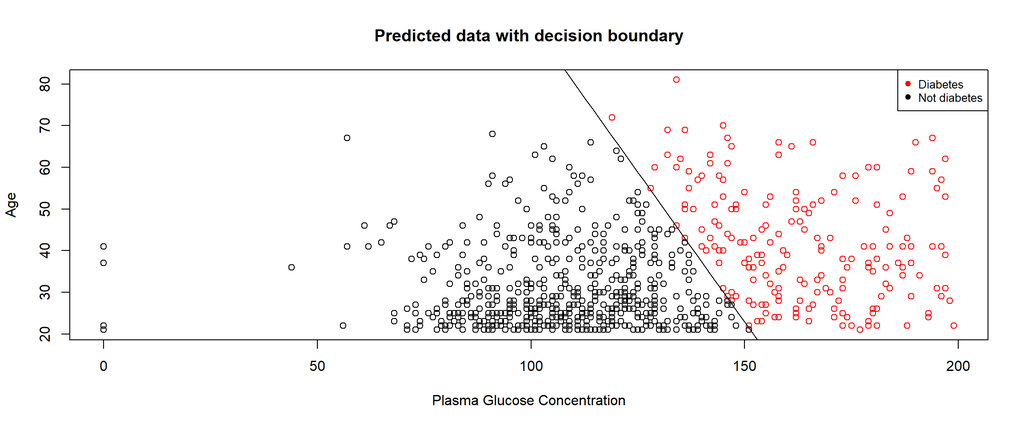

### Part 4 - Adjustment of prediction threshold

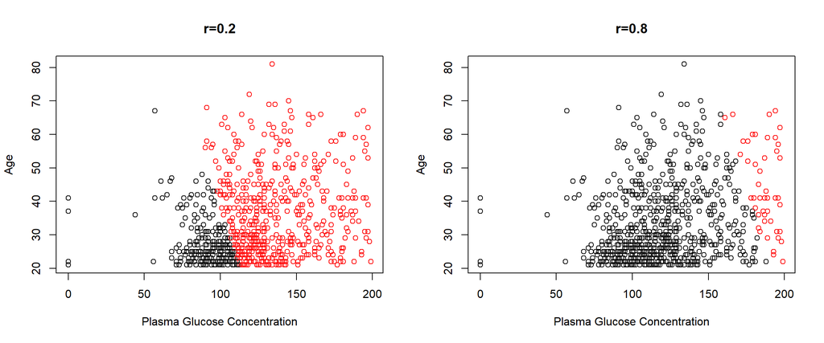

By adjusting the prediction threshold we change how confident the model needs to be to predict a point as “diabetes”.

With r=0.2 the model will predict all points that have above 20% risk of diabetes as “diabetes”. With r=0.8 the model will predict all points that have above 80% risk of diabetes as “diabetes”.

### Part 5 - Basis function expansion

In the scatterplot for the prediction from the model with expanded features the decision boundary has turned from a line to a curve. The new model allows slightly higher amounts of plasma glucose concentration for younger and older people before predicting diabetes. People in the age 40-50 are predicted with diabetes at slightly lower amounts of plasma glucose concentration.

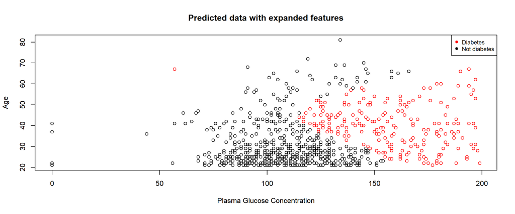

#### Comparison of missprediction between original model and model with expanded features

```
## [1] "The original model has a misclassification of  0.263020833333333  or about  26.3 %"
```

```
## [1] "The model with expanded features has a misclassification of  0.244791666666667  or about  24.48 %"
```

```
## [1] "The model with expanded features is around 1.82 % better than the original"
```

## Assignment 4

#### Why can it be important to consider various probability thresholds in the classification problems, according to the book?

While the prediction threshold which yields the lowest misclassification rate gives the most accurate predictions by percentage this is not always the most important aspect of a classifier. In real world situations it can be more important to correctly predict one classification over another. For example, you would much rather predict false positives over false negatives when predicting cancer in patients. Classifications might also appear at very different frequencies. If a specific classification is rare the misclassification rate might be the lowest when no predictions result in the rare class.

(From book page 50)